# Practical Machine Learning

Manojit Saha

25 September 2016

# Set Working Directory, Download and Load Data

```r
setwd('G:/Intro to R/Machine Learning')
training <- read.csv("pml-training.csv", na.strings=c("NA","#DIV/0!",""))
testing <- read.csv("pml-testing.csv", na.strings=c("NA","#DIV/0!",""))
```

# Include Libraries, Set Seed value for reproducibility

```r
library(caret)
```

```r
library(rpart)
library(rpart.plot)
library(RColorBrewer)
library(rattle)
library(randomForest)
library(knitr)
set.seed(55555)
```

# Clean Data

1. Delete columns (predictors) of the training set that contain any missing values
2. Remove the first seven predictors as these variables have little predicting power for the outcome classe

```r
training <- training[, colSums(is.na(training)) == 0]
testing <- testing[, colSums(is.na(testing)) == 0]

trainData <- training[, -c(1:7)]
testData <- testing[, -c(1:7)]
```

traindata: 19622 rows and 52 columns plus classe testdata: 20 rows and 52 columns plus ploblem_id

# Data Split

Training set trainData is splitted into a training set (train, 70%) for prediction and a validation set (valid 30%) to compute the out-of-sample errors.

```r
inTrain <- createDataPartition(trainData$classe, p = 0.7, list = FALSE)
train <- trainData[inTrain, ]
valid <- trainData[-inTrain, ]
```

# Prediction Algorithm

## Classification Trees

Performed 5-fold cross validation to save time and increase performance.

```r
control <- trainControl(method = "cv", number = 5)
fit_rpart <- train(classe ~ ., data = train, method = "rpart",
                   trControl = control)
print(fit_rpart, digits = 4)
```

```
## CART
##
## 13737 samples
##    52 predictor
##     5 classes: 'A', 'B', 'C', 'D', 'E'
##
## No pre-processing
## Resampling: Cross-Validated (5 fold)
## Summary of sample sizes: 10991, 10989, 10990, 10989, 10989
## Resampling results across tuning parameters:
##
##   cp       Accuracy  Kappa
##   0.03723  0.5387    0.41187
##   0.05910  0.3931    0.16968
##   0.11881  0.3339    0.07547
##
## Accuracy was used to select the optimal model using  the largest value.
## The final value used for the model was cp = 0.03723.
```

## Decision Tree

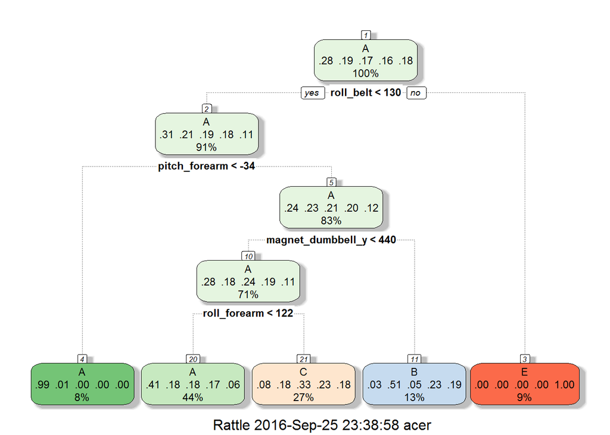

```r
fancyRpartPlot(fit_rpart$finalModel)
```

## Confusion Matrix Use confusion matrix and find how accurate the Classification Tree in this scenario

```r
predict_rpart <- predict(fit_rpart, valid)
(conf_rpart <- confusionMatrix(valid$classe, predict_rpart))
```

```
## Confusion Matrix and Statistics
##
##           Reference
## Prediction    A    B    C    D    E
##          A 1521   26  118    0    9
##          B  464  404  271    0    0
##          C  477   29  520    0    0
##          D  424  175  365    0    0
##          E  157  163  304    0  458
##
## Overall Statistics
##
##                Accuracy : 0.4933
##                  95% CI : (0.4804, 0.5061)
##     No Information Rate : 0.5171
##     P-Value [Acc > NIR] : 0.9999
##
##                   Kappa : 0.3379
##  Mcnemar's Test P-Value : NA
##
## Statistics by Class:
##
##                      Class: A Class: B Class: C Class: D Class: E
## Sensitivity            0.4998  0.50690  0.32953       NA  0.98073
## Specificity            0.9462  0.85554  0.88252   0.8362  0.88483
## Pos Pred Value         0.9086  0.35470  0.50682       NA  0.42329
## Neg Pred Value         0.6386  0.91719  0.78226       NA  0.99813
## Prevalence             0.5171  0.13543  0.26814   0.0000  0.07935
## Detection Rate         0.2585  0.06865  0.08836   0.0000  0.07782
## Detection Prevalence   0.2845  0.19354  0.17434   0.1638  0.18386
## Balanced Accuracy      0.7230  0.68122  0.60602       NA  0.93278
```

Accuracy of Confusion Matrix

```r
(accuracy_rpart <- conf_rpart$overall[1])
```

```
## Accuracy
## 0.493288
```

The accuracy is close to 50% and the quality of prediction of the cariable classe on the data set is not encouraging.

## Random forest

Applying Random Forest algorithm just to test if it gives a better prediction confidance than the Classification matrix.

```r
fit_rf <- train(classe ~ ., data = train, method = "rf", trControl = control)
print(fit_rf, digits = 4)
```

```
## Random Forest
##
## 13737 samples
##    52 predictor
##     5 classes: 'A', 'B', 'C', 'D', 'E'
##
## No pre-processing
## Resampling: Cross-Validated (5 fold)
## Summary of sample sizes: 10989, 10990, 10988, 10990, 10991
## Resampling results across tuning parameters:
##
##   mtry  Accuracy  Kappa
##    2    0.9905    0.9879
##   27    0.9898    0.9871
##   52    0.9854    0.9815
##
## Accuracy was used to select the optimal model using  the largest value.
## The final value used for the model was mtry = 2.
```

## Prediict the outcome using validation Set

```r
predict_rf <- predict(fit_rf, valid)
(conf_rf <- confusionMatrix(valid$classe, predict_rf))
```

```
## Confusion Matrix and Statistics
##
##           Reference
## Prediction    A    B    C    D    E
##          A 1671    3    0    0    0
##          B    8 1129    2    0    0
##          C    0   13 1012    1    0
##          D    0    0   15  949    0
##          E    0    0    5    3 1074
##
## Overall Statistics
##
##                Accuracy : 0.9915
##                  95% CI : (0.9888, 0.9937)
##     No Information Rate : 0.2853
##     P-Value [Acc > NIR] : < 2.2e-16
##
##                   Kappa : 0.9893
##  Mcnemar's Test P-Value : NA
##
## Statistics by Class:
##
##                      Class: A Class: B Class: C Class: D Class: E
## Sensitivity            0.9952   0.9860   0.9787   0.9958   1.0000
## Specificity            0.9993   0.9979   0.9971   0.9970   0.9983
## Pos Pred Value         0.9982   0.9912   0.9864   0.9844   0.9926
## Neg Pred Value         0.9981   0.9966   0.9955   0.9992   1.0000
## Prevalence             0.2853   0.1946   0.1757   0.1619   0.1825
## Detection Rate         0.2839   0.1918   0.1720   0.1613   0.1825
## Detection Prevalence   0.2845   0.1935   0.1743   0.1638   0.1839
## Balanced Accuracy      0.9973   0.9920   0.9879   0.9964   0.9992
```

## Accuracy from Random Forest

```r
(accuracy_rf <- conf_rf$overall[1])
```

```
##  Accuracy
## 0.9915038
```

It’s found that the confidance on the prediction through Random Forest algorithm is 99%